# Zoo Animal Classification

In this project, we will use information on various zoo animals to try and predict whether an animal is a mammal, bird, reptile, fish, amphibian, bug or invertebrate.

```python
import pandas as pd
import numpy as np
import matplotlib.pyplot as plt
```

```python
class_file = pd.read_csv("datasets/class.csv")
class_file
```

|  | Class_Number | Number_Of_Animal_Species_In_Class | Class_Type | Animal_Names |
| --- | --- | --- | --- | --- |
| 0 | 1 | 41 | Mammal | aardvark, antelope, bear, boar, buffalo, calf,... |
| 1 | 2 | 20 | Bird | chicken, crow, dove, duck, flamingo, gull, haw... |
| 2 | 3 | 5 | Reptile | pitviper, seasnake, slowworm, tortoise, tuatara |
| 3 | 4 | 13 | Fish | bass, carp, catfish, chub, dogfish, haddock, h... |
| 4 | 5 | 4 | Amphibian | frog, frog, newt, toad |
| 5 | 6 | 8 | Bug | flea, gnat, honeybee, housefly, ladybird, moth... |
| 6 | 7 | 10 | Invertebrate | clam, crab, crayfish, lobster, octopus, scorpi... |

```python
zoo_1 = pd.read_csv("datasets/zoo.csv")
zoo_1.sample(5)
```

|  | animal_name | hair | feathers | eggs | milk | airborne | aquatic | predator | toothed | backbone | breathes | venomous | fins | legs | tail | domestic | catsize | class_type |
| --- | --- | --- | --- | --- | --- | --- | --- | --- | --- | --- | --- | --- | --- | --- | --- | --- | --- | --- |
| 60 | pike | 0 | 0 | 1 | 0 | 0 | 1 | 1 | 1 | 1 | 0 | 0 | 1 | 0 | 1 | 0 | 1 | 4 |
| 9 | cavy | 1 | 0 | 0 | 1 | 0 | 0 | 0 | 1 | 1 | 1 | 0 | 0 | 4 | 0 | 1 | 0 | 1 |
| 15 | crayfish | 0 | 0 | 1 | 0 | 0 | 1 | 1 | 0 | 0 | 0 | 0 | 0 | 6 | 0 | 0 | 0 | 7 |
| 71 | rhea | 0 | 1 | 1 | 0 | 0 | 0 | 1 | 0 | 1 | 1 | 0 | 0 | 2 | 1 | 0 | 1 | 2 |
| 0 | aardvark | 1 | 0 | 0 | 1 | 0 | 0 | 1 | 1 | 1 | 1 | 0 | 0 | 4 | 0 | 0 | 1 | 1 |

```python
zoo_2 = pd.read_csv("datasets/zoo2.csv")
zoo_2.sample(5)
```

|  | animal_name | hair | feathers | eggs | milk | airborne | aquatic | predator | toothed | backbone | breathes | venomous | fins | legs | tail | domestic | catsize | class_type |
| --- | --- | --- | --- | --- | --- | --- | --- | --- | --- | --- | --- | --- | --- | --- | --- | --- | --- | --- |
| 19 | salamander | 0 | 0 | 1 | 0 | 0 | 1 | 0 | 1 | 1 | 1 | 0 | 0 | 4 | 1 | 1 | 0 | 5 |
| 29 | butterfly | 1 | 0 | 1 | 0 | 1 | 0 | 0 | 0 | 0 | 1 | 0 | 0 | 6 | 0 | 0 | 0 | 6 |
| 5 | python | 0 | 0 | 1 | 0 | 0 | 0 | 1 | 1 | 1 | 1 | 1 | 0 | 0 | 1 | 0 | 1 | 3 |
| 38 | spider | 0 | 0 | 1 | 0 | 0 | 0 | 1 | 1 | 0 | 1 | 1 | 0 | 8 | 0 | 0 | 0 | 7 |
| 25 | mosquito | 0 | 0 | 1 | 0 | 1 | 0 | 0 | 0 | 0 | 1 | 0 | 0 | 6 | 0 | 0 | 0 | 6 |

```python
zoo_3 = pd.read_csv("datasets/zoo3.csv")
zoo_3.sample(5)
```

|  | animal_name | hair | feathers | eggs | milk | airborne | aquatic | predator | toothed | backbone | breathes | venomous | fins | legs | tail | domestic | catsize | class_type |
| --- | --- | --- | --- | --- | --- | --- | --- | --- | --- | --- | --- | --- | --- | --- | --- | --- | --- | --- |
| 36 | pavo | 0 | 1 | 1 | 0 | 1 | 0 | 0 | 0 | 1 | 1 | 0 | 0 | 2 | 1 | 0 | 1 | 2 |
| 23 | chaua | 0 | 1 | 1 | 0 | 1 | 0 | 0 | 0 | 1 | 1 | 0 | 0 | 2 | 1 | 1 | 1 | 2 |
| 13 | onca-pintada | 1 | 0 | 0 | 1 | 0 | 0 | 1 | 1 | 1 | 1 | 0 | 0 | 4 | 1 | 0 | 0 | 1 |
| 20 | aracari-banana | 0 | 1 | 1 | 0 | 1 | 0 | 0 | 0 | 1 | 1 | 0 | 0 | 2 | 1 | 0 | 0 | 2 |
| 17 | tamandua-bandeira | 1 | 0 | 0 | 1 | 0 | 0 | 0 | 0 | 1 | 1 | 0 | 0 | 4 | 1 | 0 | 0 | 1 |

```python
# combined dataframe
zoo = pd.concat([zoo_1, zoo_2, zoo_3], axis=0)
zoo.sample(5)
```

|  | animal_name | hair | feathers | eggs | milk | airborne | aquatic | predator | toothed | backbone | breathes | venomous | fins | legs | tail | domestic | catsize | class_type |
| --- | --- | --- | --- | --- | --- | --- | --- | --- | --- | --- | --- | --- | --- | --- | --- | --- | --- | --- |
| 76 | seasnake | 0 | 0 | 0 | 0 | 0 | 1 | 1 | 1 | 1 | 0 | 1 | 0 | 0 | 1 | 0 | 0 | 3 |
| 24 | wart toad | 0 | 0 | 1 | 0 | 0 | 1 | 0 | 1 | 1 | 1 | 0 | 0 | 4 | 0 | 0 | 0 | 5 |
| 30 | jandaia-amarela | 0 | 1 | 1 | 0 | 1 | 0 | 0 | 0 | 1 | 1 | 0 | 0 | 2 | 1 | 0 | 0 | 2 |
| 13 | clam | 0 | 0 | 1 | 0 | 0 | 0 | 1 | 0 | 0 | 0 | 0 | 0 | 0 | 0 | 0 | 0 | 7 |
| 74 | seal | 1 | 0 | 0 | 1 | 0 | 1 | 1 | 1 | 1 | 1 | 0 | 1 | 0 | 0 | 0 | 1 | 1 |

```python
zoo_1.shape, zoo_2.shape, zoo_3.shape
```

```
((101, 18), (43, 18), (70, 18))
```

```python
zoo.shape
```

```
(214, 18)
```

With only 214 records in total, our dataset is quite small, not ideal for machine learning as models trained on a small number of observations tend to overfit and might not perform well on test data and new records.

```python
# shuffled dataframe
zoo = zoo.sample(frac=1)
zoo.reset_index(drop=True, inplace=True)
```

```python
zoo.head()
```

|  | animal_name | hair | feathers | eggs | milk | airborne | aquatic | predator | toothed | backbone | breathes | venomous | fins | legs | tail | domestic | catsize | class_type |
| --- | --- | --- | --- | --- | --- | --- | --- | --- | --- | --- | --- | --- | --- | --- | --- | --- | --- | --- |
| 0 | toad | 0 | 0 | 1 | 0 | 0 | 1 | 0 | 1 | 1 | 1 | 0 | 0 | 4 | 0 | 0 | 0 | 5 |
| 1 | cobra-cipo | 0 | 0 | 1 | 0 | 0 | 0 | 1 | 1 | 1 | 1 | 0 | 0 | 0 | 1 | 0 | 0 | 3 |
| 2 | dove | 0 | 1 | 1 | 0 | 1 | 0 | 0 | 0 | 1 | 1 | 0 | 0 | 2 | 1 | 1 | 0 | 2 |
| 3 | squid | 0 | 0 | 1 | 0 | 0 | 1 | 0 | 0 | 0 | 0 | 0 | 0 | 0 | 0 | 0 | 1 | 7 |
| 4 | hornet | 0 | 0 | 1 | 0 | 1 | 0 | 1 | 0 | 0 | 1 | 1 | 0 | 6 | 0 | 0 | 0 | 6 |

```python
for i in zoo["class_type"].unique():

    print("Class Number: ", i)

    class_type = class_file[class_file["Class_Number"] == i]["Class_Type"].values[0]
    print("Class Type: ", class_type)

    print("{} Records: ".format(class_type), zoo["class_type"].value_counts()[i])

    unique = zoo[zoo["class_type"] == i]["animal_name"].unique()
    print("Unique {} Species: ".format(class_type), len(unique))
    print("Unique {} Names: ".format(class_type), unique)

    print("\n")
```

```
Class Number:  5
Class Type:  Amphibian
Amphibian Records:  16
Unique Amphibian Species:  15
Unique Amphibian Names:  ['toad' 'frog' 'sapo-barriga-de-fogo' 'sapo-de-chifre' 'salamander'
 'ra-pimenta' 'wart toad' 'newt' 'perereca-de-alcatrazes' 'siren'
 'dart frog' 'sapo-cururu' 'firebelly' 'ra-flecha-azul' 'tree frog']


Class Number:  3
Class Type:  Reptile
Reptile Records:  25
Unique Reptile Species:  25
Unique Reptile Names:  ['cobra-cipo' 'jiboia' 'slowworm' 'turtle' 'tortoise' 'adder' 'sucuri'
 'tracaja' 'jacare-coroa' 'lizard' 'iguana' 'alligator' 'gecko' 'python'
 'boa' 'tuatara' 'gharial' 'jararaca-ilhoa' 'jabuti' 'seasnake' 'pitviper'
 'urutu-cruzeiro' 'chameleon' 'crocodile' 'skink']


Class Number:  2
Class Type:  Bird
Bird Records:  40
Unique Bird Species:  40
Unique Bird Names:  ['dove' 'aracari-banana' 'arara-azul' 'rhea' 'gaviao-pombo' 'gull'
 'urubu-rei' 'murucututu' 'chicken' 'jacutinga' 'vulture' 'jacurutu'
 'duck' 'papagaio-de-cara-roxa' 'jandaia-amarela' 'tucano-de-bico-preto'
 'wren' 'aguia-cinzenta' 'parakeet' 'pavo' 'swan' 'chaua' 'guara'
 'pheasant' 'ema' 'flamingo' 'skimmer' 'lark' 'arara-caninde' 'harpia'
 'ostrich' 'kiwi' 'pato-de-crista' 'sparrow' 'penguin' 'macuco' 'mutum'
 'hawk' 'crow' 'skua']


Class Number:  7
Class Type:  Invertebrate
Invertebrate Records:  20
Unique Invertebrate Species:  20
Unique Invertebrate Names:  ['squid' 'sauva-limao' 'seawasp' 'crab' 'scallop' 'clam' 'slug' 'scorpion'
 'lobster' 'silkworm' 'octopus' 'snail' 'spider' 'caranguejeira'
 'caracol-da-mata-atlantica' 'crayfish' 'jellyfish' 'starfish' 'bicho-pau'
 'worm']
```

[output cut: 22 more lines]

```
 'queixada' 'antelope' 'bugio' 'peixe-boi' 'gato-maracaja' 'mongoose'
 'reindeer' 'vole' 'girl' 'oryx' 'mono-carvoeiro' 'mink' 'wolf' 'raccoon'
 'cavy' 'urso-de-oculos' 'puma' 'dolphin' 'goat' 'bear' 'squirrel' 'pony'
 'onca-pintada']


Class Number:  4
Class Type:  Fish
Fish Records:  28
Unique Fish Species:  28
Unique Fish Names:  ['barracuda' 'dogfish' 'tuna' 'stingray' 'pirarucu' 'carp' 'pike'
 'haddock' 'trout' 'cascudinho-de-caverna' 'baiacu' 'halibut' 'lambari'
 'raia-chita' 'anchovy' 'tubarao-raposa' 'bass' 'marlin' 'catfish'
 'piranha' 'herring' 'tambaqui' 'seahorse' 'flounder' 'chub' 'matrinxa'
 'sole' 'mackerel']
```

The number of records per class type in our dataset varies greatly, with 60 for mammals down to only 16 for amphibians. This imbalance might translate into our ML models.

```python
# there are two frog entries in the dataset
zoo[zoo.duplicated(subset="animal_name", keep=False)]
```

|  | animal_name | hair | feathers | eggs | milk | airborne | aquatic | predator | toothed | backbone | breathes | venomous | fins | legs | tail | domestic | catsize | class_type |
| --- | --- | --- | --- | --- | --- | --- | --- | --- | --- | --- | --- | --- | --- | --- | --- | --- | --- | --- |
| 19 | frog | 0 | 0 | 1 | 0 | 0 | 1 | 1 | 1 | 1 | 1 | 0 | 0 | 4 | 0 | 0 | 0 | 5 |
| 158 | frog | 0 | 0 | 1 | 0 | 0 | 1 | 1 | 1 | 1 | 1 | 1 | 0 | 4 | 0 | 0 | 0 | 5 |

```python
# renaming the venomous frog to create two distinct entries
zoo.loc[((zoo["venomous"] == 1) & (zoo["animal_name"] == "frog")), "animal_name"] = "venomous frog"
```

```python
zoo[zoo["animal_name"]=="venomous frog"]
```

|  | animal_name | hair | feathers | eggs | milk | airborne | aquatic | predator | toothed | backbone | breathes | venomous | fins | legs | tail | domestic | catsize | class_type |
| --- | --- | --- | --- | --- | --- | --- | --- | --- | --- | --- | --- | --- | --- | --- | --- | --- | --- | --- |
| 158 | venomous frog | 0 | 0 | 1 | 0 | 0 | 1 | 1 | 1 | 1 | 1 | 1 | 0 | 4 | 0 | 0 | 0 | 5 |

```python
cols = list(zoo.columns)
cols = cols[1:-1]  # removing animal_name and class_type columns from cols list
```

```python
# mammals
for column in cols:
    options = zoo[zoo["class_type"] == 1][column].unique()
    print(column, options)
```

```
hair [1 0]
feathers [0]
eggs [0 1]
milk [1]
airborne [0 1]
aquatic [0 1]
predator [1 0]
toothed [1 0]
backbone [1]
breathes [1]
venomous [0]
fins [0 1]
legs [4 2 0]
tail [1 0]
domestic [0 1]
catsize [1 0]
```

```python
# mammals - one option only for categories feathers, milk, backbone, breathes and venomous
for column in cols:
    options = zoo[zoo["class_type"] == 1][column].unique()
    if len(options) <= 1:
        print(column, options)
```

```
feathers [0]
milk [1]
backbone [1]
breathes [1]
venomous [0]
```

```python
for i in zoo["class_type"].unique():

    class_type = class_file[class_file["Class_Number"] == i]["Class_Type"].values[0]

    print(class_type)
    for column in cols:
        options = zoo[zoo["class_type"] == i][column].unique()
        if len(options) <= 1:
            print(column, options)
    print("\n")
```

```
Amphibian
hair [0]
feathers [0]
eggs [1]
milk [0]
airborne [0]
aquatic [1]
backbone [1]
breathes [1]
fins [0]


Reptile
hair [0]
feathers [0]
milk [0]
airborne [0]
backbone [1]
fins [0]


Bird
hair [0]
feathers [1]
eggs [1]
milk [0]
toothed [0]
backbone [1]
breathes [1]
venomous [0]
fins [0]
legs [2]


Invertebrate
feathers [0]
milk [0]
airborne [0]
backbone [0]
fins [0]
```

[output cut: 21 more lines]

```
breathes [1]
venomous [0]


Fish
hair [0]
feathers [0]
eggs [1]
milk [0]
airborne [0]
aquatic [1]
backbone [1]
fins [1]
legs [0]
tail [1]
```

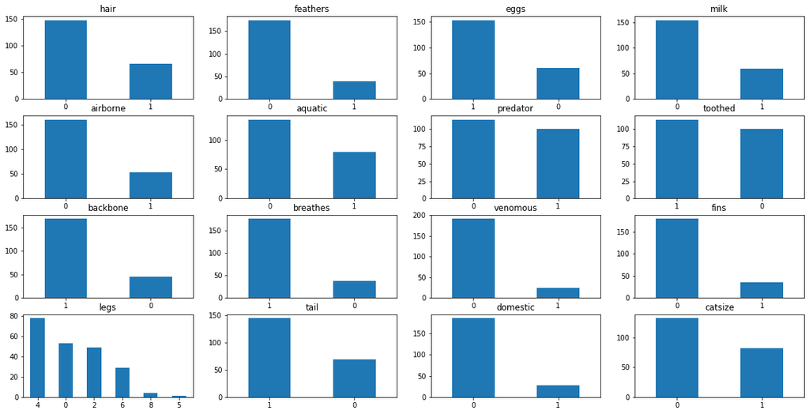

```python
fig = plt.figure(figsize=(20, 10))
i=1

for column in cols:
    plt.subplot(4, 4, i)
    zoo[column].value_counts().plot.bar(rot=0, subplots=True)
    i+=1
```

Classification

```python
features = zoo.drop(columns=["animal_name", "class_type"], axis=1)
target = zoo["class_type"]
```

```python
from sklearn.model_selection import train_test_split
```

```python
# train test split
x_train, x_test, y_train, y_test = train_test_split(features, target, test_size=0.2)
```

```python
print(x_train.shape, x_test.shape)
print(y_train.shape, y_test.shape)
```

```
(171, 16) (43, 16)
(171,) (43,)
```

```python
from sklearn.neighbors import KNeighborsClassifier
from sklearn.linear_model import LogisticRegression
from sklearn.svm import SVC
from sklearn.naive_bayes import GaussianNB
from sklearn.ensemble import RandomForestClassifier
```

```python
# classifiers
clf1 = KNeighborsClassifier(n_neighbors=5)
clf2 = LogisticRegression(max_iter=200)
clf3 = SVC()
clf4 = GaussianNB()
clf5 = RandomForestClassifier(n_estimators=50)
```

```python
classifiers = [clf1, clf2, clf3, clf4, clf5]
```

```python
for clf in classifiers:
    clf.fit(x_train, y_train)
```

```python
predictions_df = pd.DataFrame()

predictions_df["Actual Label"] = y_test

for clf in classifiers:
    y_pred = clf.predict(x_test)
    predictions_df[clf.__class__.__name__] = y_pred

predictions_df.sample(5)
```

|  | Actual Label | KNeighborsClassifier | LogisticRegression | SVC | GaussianNB | RandomForestClassifier |
| --- | --- | --- | --- | --- | --- | --- |
| 42 | 1 | 1 | 1 | 1 | 1 | 1 |
| 35 | 5 | 3 | 3 | 3 | 5 | 3 |
| 204 | 7 | 7 | 7 | 7 | 7 | 7 |
| 101 | 7 | 7 | 7 | 7 | 7 | 7 |
| 165 | 2 | 2 | 2 | 2 | 2 | 2 |

```python
from sklearn.metrics import accuracy_score
```

```python
for clf in classifiers:
    y_pred = clf.predict(x_test)
    print(clf.__class__.__name__, accuracy_score(y_test, y_pred))
```

```
KNeighborsClassifier 0.9534883720930233
LogisticRegression 0.9534883720930233
SVC 0.9534883720930233
GaussianNB 0.9534883720930233
RandomForestClassifier 0.9534883720930233
```

```python
merged_df = predictions_df.join(zoo["animal_name"])
merged_df.reset_index(drop=True, inplace=True)
merged_df.sample(5)
```

|  | Actual Label | KNeighborsClassifier | LogisticRegression | SVC | GaussianNB | RandomForestClassifier | animal_name |
| --- | --- | --- | --- | --- | --- | --- | --- |
| 9 | 4 | 4 | 4 | 4 | 4 | 4 | tambaqui |
| 40 | 1 | 1 | 1 | 1 | 1 | 1 | orangotango |
| 34 | 2 | 2 | 2 | 2 | 2 | 2 | hawk |
| 5 | 6 | 6 | 6 | 6 | 6 | 6 | palmetto |
| 13 | 1 | 1 | 1 | 1 | 1 | 1 | goat |

```python
wrong_df = pd.DataFrame()

for col in merged_df.columns[1:-1]:
    wrong = merged_df[merged_df["Actual Label"] != merged_df[col]]
    wrong_df = pd.concat([wrong_df, wrong], axis=0)
```

```python
wrong_df.drop_duplicates(inplace=True)
wrong_df
```

|  | Actual Label | KNeighborsClassifier | LogisticRegression | SVC | GaussianNB | RandomForestClassifier | animal_name |
| --- | --- | --- | --- | --- | --- | --- | --- |
| 26 | 5 | 3 | 3 | 3 | 5 | 3 | newt |
| 30 | 5 | 3 | 3 | 3 | 5 | 3 | salamander |
| 4 | 3 | 3 | 3 | 3 | 5 | 3 | gharial |
| 17 | 3 | 3 | 3 | 3 | 5 | 3 | alligator |

```python
for col in merged_df.columns[1:-1]:
    incorrect = merged_df[merged_df["Actual Label"] != merged_df[col]]
    print("Number of Incorrect Predictions - {}: ".format(col), len(incorrect))
```

```
Number of Incorrect Predictions - KNeighborsClassifier:  2
Number of Incorrect Predictions - LogisticRegression:  2
Number of Incorrect Predictions - SVC:  2
Number of Incorrect Predictions - GaussianNB:  2
Number of Incorrect Predictions - RandomForestClassifier:  2
```

Let's see if ensemble learning - and more precisely model stacking - can give us better prediction accuracy.

```python
features = zoo.drop(columns=["animal_name", "class_type"], axis=1)
target = zoo["class_type"]
```

```python
# train: 60% - used to train the predictors of the first layer
# holdout: 30% - used by first layer predictors to make predictions
# test: 10% - used to evaluate the meta learner predictions
x_train, x_hold_out, x_test  = np.split(features, [int(.6*len(features)), int(.9*len(features))])
y_train, y_hold_out, y_test  = np.split(target, [int(.6*len(target)), int(.9*len(target))])
```

```python
x_train.shape, x_hold_out.shape, x_test.shape
```

```
((128, 16), (64, 16), (22, 16))
```

```python
# first layer predictors
clf1 = KNeighborsClassifier(n_neighbors=10)
clf2 = SVC()
clf3 = GaussianNB()

first_layer = [clf1, clf2, clf3]

for clf in first_layer:
    clf.fit(x_train, y_train)
```

```python
# helper function
def get_predictions(x,y):

    pred_df = pd.DataFrame()

    for clf in first_layer:
        y_pred = clf.predict(x)
        pred_df[clf.__class__.__name__] = y_pred

        # print accuracy
        print(clf.__class__.__name__, accuracy_score(y, y_pred))

    return pred_df
```

```python
# get predictions on hold-out data
prediction_hold_out = get_predictions(x_hold_out, y_hold_out)
```

```
KNeighborsClassifier 0.90625
SVC 0.953125
GaussianNB 0.890625
```

```python
prediction_hold_out.sample(5)
```

|  | KNeighborsClassifier | SVC | GaussianNB |
| --- | --- | --- | --- |
| 58 | 5 | 5 | 5 |
| 40 | 4 | 4 | 4 |
| 9 | 5 | 5 | 5 |
| 38 | 7 | 7 | 7 |
| 49 | 1 | 1 | 1 |

```python
# setting up training data and target values for our meta learner
x_train_stack = prediction_hold_out
y_train_stack = y_hold_out
```

```python
# instantiating meta learner (LogisticRegression classifier model)
classifier_stack = LogisticRegression(solver="liblinear", max_iter=300)
classifier_stack.fit(x_train_stack, y_train_stack)
```

```
LogisticRegression(max_iter=300, solver='liblinear')
```

```python
# using the ensemble for prediction - step 1: getting the predictions from our first layer models
prediction_test = get_predictions(x_test, y_test)
```

```
KNeighborsClassifier 0.7727272727272727
SVC 0.8636363636363636
GaussianNB 0.9090909090909091
```

```python
# using the ensemble for prediction - step 2: feeding the predictions into our meta learner model
x_stack_test = prediction_test
y_stack_pred = classifier_stack.predict(x_stack_test)
```

```python
# calculating accuracy
accuracy_score(y_test, y_stack_pred)
```

```
0.7727272727272727
```

Dataframe:

```python
df = pd.concat([pd.Series(y_test.values), prediction_test, pd.Series(y_stack_pred)], axis=1)
df = df.rename(columns={0:"Actual Label", 1: "Meta Learner"})
df[df["Actual Label"] != df["Meta Learner"]]
```

|  | Actual Label | KNeighborsClassifier | SVC | GaussianNB | Meta Learner |
| --- | --- | --- | --- | --- | --- |
| 1 | 1 | 4 | 1 | 1 | 2 |
| 2 | 3 | 3 | 3 | 3 | 4 |
| 11 | 7 | 6 | 6 | 6 | 6 |
| 12 | 7 | 7 | 7 | 7 | 6 |
| 16 | 3 | 5 | 5 | 3 | 5 |

Instead of a stacking model, let's try hard voting.

```python
from sklearn.ensemble import VotingClassifier
```

```python
log_clf = LogisticRegression(solver="liblinear")
svc_clf = SVC(kernel="linear")
naive_clf = GaussianNB()
```

```python
hard_voting_clf = VotingClassifier(estimators=[("lr", log_clf),
                                               ("svc", svc_clf),
                                               ("naive", naive_clf)],
                                   voting="hard")
```

```python
x_train, x_test, y_train, y_test = train_test_split(features, target, test_size=0.2)
```

```python
for classifier in (log_clf, svc_clf, naive_clf, hard_voting_clf):

    classifier.fit(x_train, y_train)
    y_pred = classifier.predict(x_test)

    print(classifier.__class__.__name__, accuracy_score(y_test, y_pred))
```

```
LogisticRegression 0.9302325581395349
SVC 0.9534883720930233
GaussianNB 0.9534883720930233
VotingClassifier 0.9302325581395349
```

Our voting classifier performs better than our meta learner, but again we don't really see an improvement over the accuracy of the individual learners.

Let's try one more ensemble learning technique - bagging - which is an averaging technique where individual models in the ensemble are trained on different random subsets of the training data, sampled with replacement.

```python
from sklearn.tree import DecisionTreeClassifier
from sklearn.ensemble import BaggingClassifier
```

```python
bag_clf = BaggingClassifier(DecisionTreeClassifier(), # algorithm
                            n_estimators = 400,       # number of predictors in ensemble
                            bootstrap = True,         # bagging
                            max_samples = 0.7,        # use 70% of the training data for each predictor
                            n_jobs = -1,
                            oob_score = True)
```

```python
bag_clf.fit(x_train, y_train)
```

```
BaggingClassifier(base_estimator=DecisionTreeClassifier(), max_samples=0.7,
                  n_estimators=400, n_jobs=-1, oob_score=True)
```

```python
# out-of-bag evaluation OOB: for each individual predictor in the ensemble, all of the instances that were not used
# during training are used to evaluate the predictor.
bag_clf.oob_score_
```

```
0.9532163742690059
```

```python
y_pred = bag_clf.predict(x_test)
accuracy_score(y_test, y_pred)
```

```
0.9534883720930233
```

None of our ensembling techniques (use of meta learner, hard voting and bagging) allowed us to improve prediction accuracy over the results of the individual learners. Model stacking performed particularly poorly and hard voting and bagging achived at best the same accuracy as the top performing individual learner.